# R Notebook

# MVP

## Hypothesis testing - practical

You work for an animal conservation organisation and are looking to do some investigating into some of the animals to provide evidence for some projects you are looking to run.

In this homework we’ll use the `msleep` data set provided in the `ggplot` package. It concerns the sleeping patterns of various types of mammal.

- Explore the dataset and familiarise yourself with it.
- Jabberwockies sleep for around $7$ hours a night, on average. Perform an appropriate statistical test to determine whether the mean `sleep_total` in the sampled population of animal types differs from the typical value for jabberwockies.
- Perform an appropriate statistical test to determine whether omnivores sleep for significantly longer than herbivores, on average.
- Perform an appropriate statistical test to determine whether the proportion of domesticated animal types in the population of animal types is greater than $5\%$.  
  [**Hint** - think about creating an `is_domesticated` variable for the analysis]

```r
library(tidyverse)
library(infer)
head(msleep)
```

| name | genus | vore | order | conservation | sleep_total | sleep_rem | sleep_cycle | awake | brainwt | bodywt |
| --- | --- | --- | --- | --- | --- | --- | --- | --- | --- | --- |
| Cheetah | Acinonyx | carni | Carnivora | lc | 12.1 | NA | NA | 11.9 | NA | 50.000 |
| Owl monkey | Aotus | omni | Primates | NA | 17.0 | 1.8 | NA | 7.0 | 0.01550 | 0.480 |
| Mountain beaver | Aplodontia | herbi | Rodentia | nt | 14.4 | 2.4 | NA | 9.6 | NA | 1.350 |
| Greater short-tailed shrew | Blarina | omni | Soricomorpha | lc | 14.9 | 2.3 | 0.1333333 | 9.1 | 0.00029 | 0.019 |
| Cow | Bos | herbi | Artiodactyla | domesticated | 4.0 | 0.7 | 0.6666667 | 20.0 | 0.42300 | 600.000 |
| Three-toed sloth | Bradypus | herbi | Pilosa | NA | 14.4 | 2.2 | 0.7666667 | 9.6 | NA | 3.850 |

```r
# unique(msleep$sleep_total) %>% sort()
```

# Task 1 one_sample hypothesis test for mean

Jabberwockies sleep for around $7$ hours a night, on average. Perform an appropriate statistical test to determine whether the mean `sleep_total` in the sampled population of animal types differs from the typical value for jabberwockies.

# 1. Define the significance level

α = 0.05

# 2. Define the Hypothesis

H0: μ (sleep_total) = 7 # Every animal in our sample sleeps on average the same total ours as Jabberwockies Ha: μ (sleep_total) ≠ 7

we’re using H0 to simulate the null sampling distribution

# 3. Visualise the distribution of the sleep_total values (histogram, boxplot)

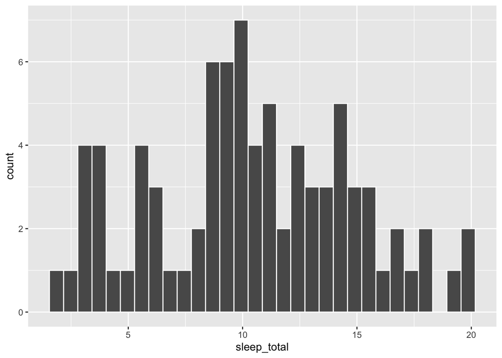

```r
msleep %>%
  ggplot() +
  aes(x = sleep_total) %>%
  geom_histogram(col = "white")
```

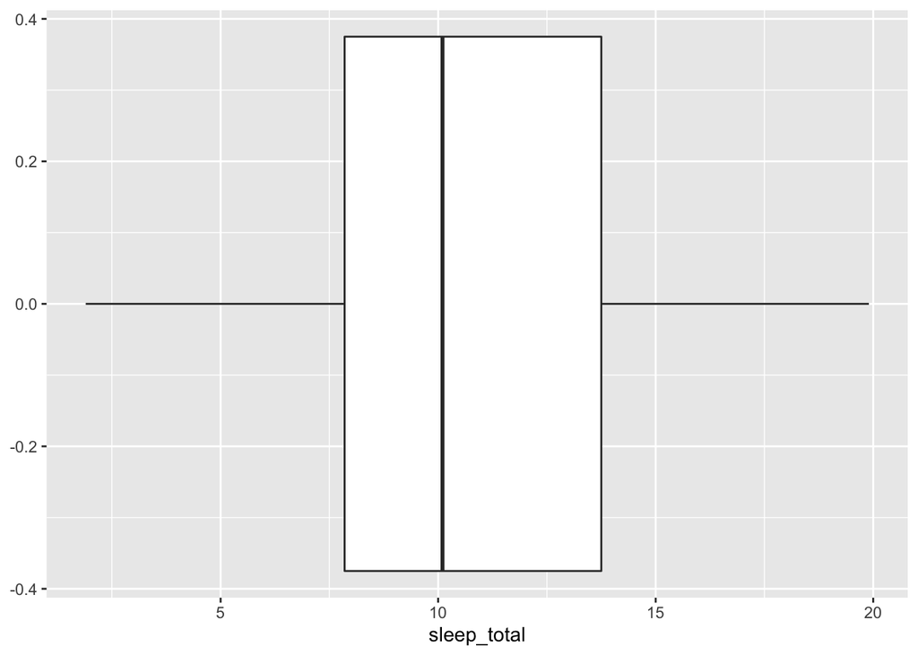

```r
msleep %>%
  ggplot() +
  aes(x = sleep_total) %>%
  geom_boxplot()
```

# 4. Calculate observed statistic from our sample

```r
observed_stat <- msleep %>%
  summarise(mean_sleep = mean(sleep_total))

observed_stat
```

| mean_sleep |
| --- |
| 10.43373 |

# 5. Calculate the null distribution

null distribution = the sampling distribution we would expect if H0 were true

```r
# add in extra step: hypothesize()
# "point" and "mu" tell `infer` to centre the null distribution at 7
# because this is our null hypothesis: that the mean average_rating is 7
null_distribution <- msleep %>%
  specify(response = sleep_total) %>%
  hypothesize(null = "point", mu = 7) %>%
  generate(reps = 10000, type = "bootstrap") %>%
  calculate(stat = "mean")
```

# 6. Visualise the null distribution and observed statistic

The observed statistic is marked with a red line

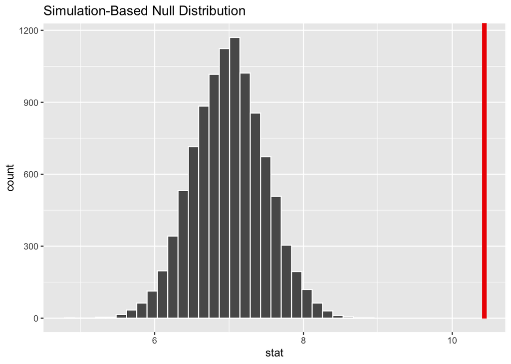

```r
null_distribution %>%
  visualise(bins = 30) +
  shade_p_value(obs_stat = observed_stat$mean_sleep, direction = "both")
```

# 7. Calculate p-value

```r
p_value <- null_distribution %>%
  get_p_value(obs_stat = observed_stat$mean_sleep, direction = "both")
p_value
```

| p_value |
| --- |
| 0 |

# 8. Conclusion

p-value < 0.05, we reject H0 in favour of Ha We found enough evidence in the sample to suggest that the mean sleep_total in the sampled population of animal types statistically significantly differs from the typical value for jabberwockies.

# Task 2 independent two-sample one-tailed tests

Perform an appropriate statistical test to determine whether omnivores sleep for significantly longer than herbivores, on average.

```r
msleep_omni_herbi <- msleep %>%
  filter(vore == "omni" | vore == "herbi")
```

independent two-sample one-tailed tests

H0: μ (omni_sleep_total) - μ (herbi_sleep_total) = 0 # The vore of the animal has no bearing on the length of average sleep Ha: μ (omni_sleep_total) - μ (herbi_sleep_total) > 0 # Omnivores sleep for significantly longer than herbivores

```r
# check size of both samples
msleep_omni_herbi %>%
  group_by(vore) %>%
  summarise(size = n())
```

| vore | size |
| --- | --- |
| herbi | 32 |
| omni | 20 |

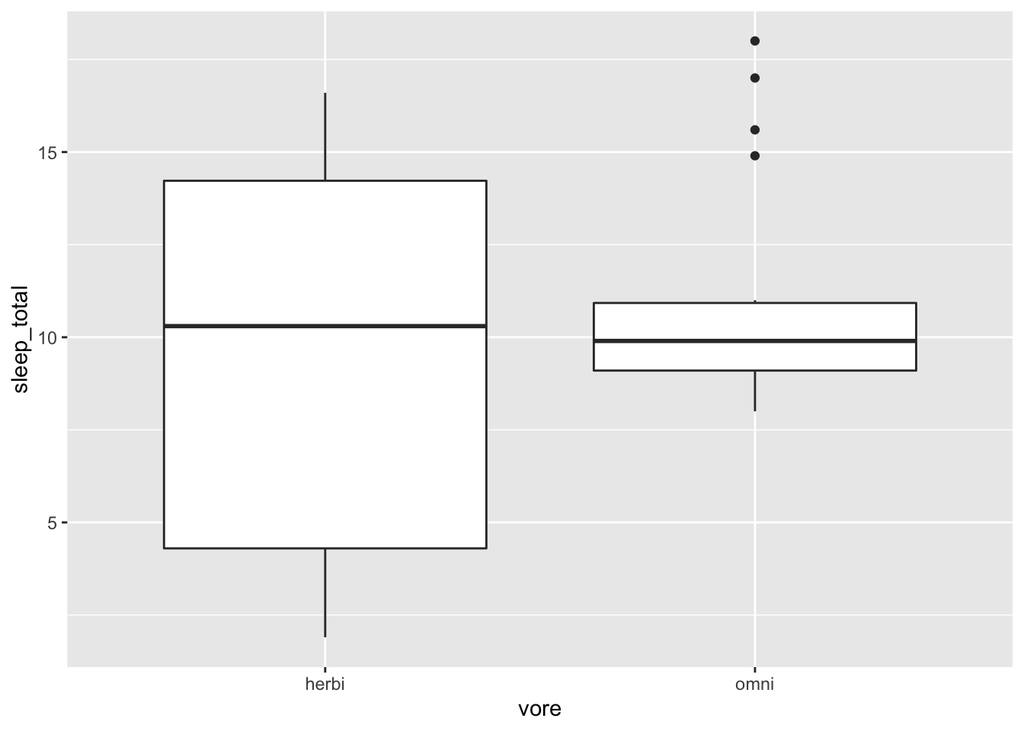

```r
# boxplot visualisation of our two samples
# Herbi sample consists of 32 observations, the distribution of data points sleep_total is widely spread.
# Omni sample consists of just 20 samples, the data points are pretty centered around the median. Box plot indicates we have 4 outliers in our sample.
msleep_omni_herbi %>%
  ggplot() +
  aes(x = sleep_total, y = vore) +
  geom_boxplot() +
  coord_flip()
```

```r
# Null distribution
null_distribution <- msleep_omni_herbi %>%
  specify(response = sleep_total, explanatory = vore) %>%  # sleep_total varies with vore category
  hypothesise(null = "independence") %>%
  generate(reps = 1000, type = "permute") %>% # shuffling the vore categories
  calculate(stat = "diff in means", order = c("omni", "herbi")) # calculates the difference between the mean of the herbi and omni samples.

head(null_distribution)
```

| replicate | stat |
| --- | --- |
| 1 | 1.050000 |
| 2 | -0.258125 |
| 3 | 2.155000 |
| 4 | 1.399375 |
| 5 | -0.696875 |
| 6 | 1.423750 |

```r
observed_stat <- msleep_omni_herbi %>%
  specify(response = sleep_total, explanatory = vore) %>%
  calculate(stat = "diff in means", order = c("omni", "herbi"))

observed_stat
```

| stat |
| --- |
| 1.415625 |

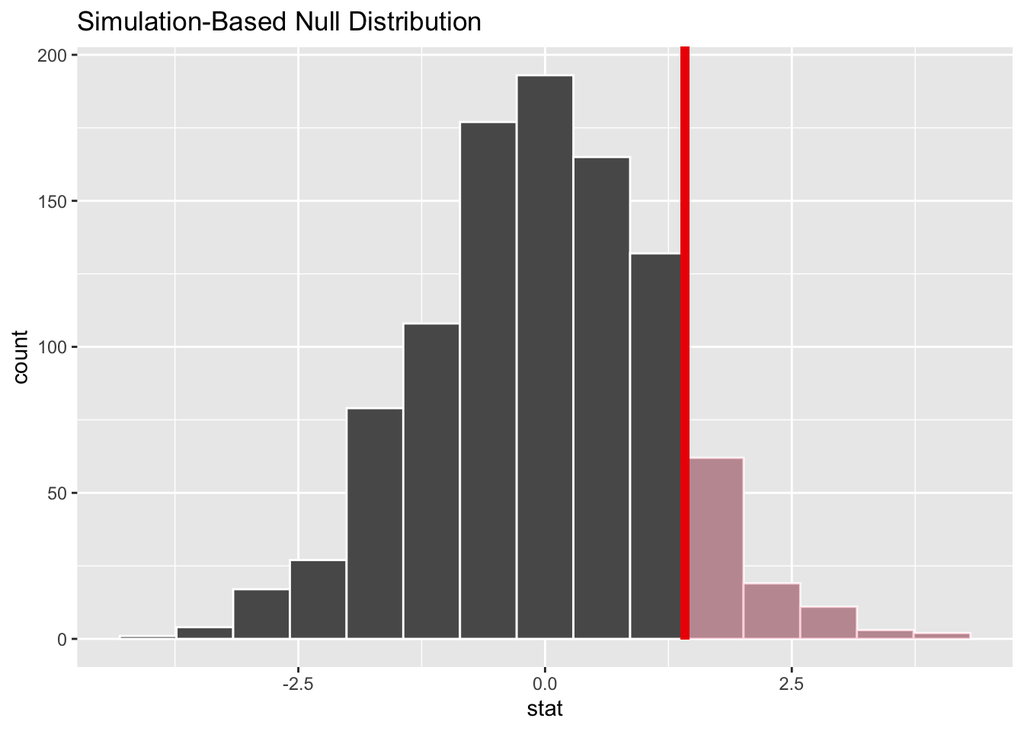

```r
# Our observed statistic lies toward the right hand edge of the null distribution
null_distribution %>%
  visualise() +
  shade_p_value(obs_stat = observed_stat, direction = "right")
```

```r
p_value <- null_distribution %>%
  get_p_value(obs_stat = observed_stat, direction = "right")

p_value
```

| p_value |
| --- |
| 0.1 |

# Task 3 one-sample hypothesis test for proportions

Perform an appropriate statistical test to determine whether the proportion of domesticated animal types in the population of animal types is greater than $5\%$.  
[**Hint** - think about creating an `is_domesticated` variable for the analysis]

α = 0.05 H0: π (domesticated) = 0.05 # The proportion of domesticated animal types in the population of animal types is equal to 5% Ha: π (domesticated) > 0.05 # the proportion of domesticated animal types in the population of animal types is greater than 5%

```r
msleep_prop <- msleep %>%
  filter(!is.na(conservation)) %>%
  mutate(is_domesticated = ifelse(conservation == "domesticated", "yes", "no"))

# pretty small sample of animal types :(
msleep_prop %>%
  group_by(is_domesticated) %>%
  summarise(count = n())
```

| is_domesticated | count |
| --- | --- |
| no | 44 |
| yes | 10 |

```r
# generate null distribution by simulation
null_distribution <- msleep_prop %>%
  specify(response = is_domesticated, success = "yes") %>%
  hypothesize(null = "point", p = 0.05) %>%
  generate(reps = 5000, type = "simulate") %>%
  calculate(stat = "prop") #we specify that the stat is proportion

null_distribution
```

| replicate | stat |
| --- | --- |
| 1 | 0.09259259 |
| 2 | 0.03703704 |
| 3 | 0.05555556 |
| 4 | 0.05555556 |
| 5 | 0.05555556 |
| 6 | 0.07407407 |
| 7 | 0.01851852 |
| 8 | 0.07407407 |
| 9 | 0.07407407 |
| 10 | 0.18518519 |

[output cut: 4990 more lines]

```r
observed_stat <- msleep_prop %>%
  specify(response = is_domesticated, success = "yes") %>%
  calculate(stat = "prop")

observed_stat
```

| stat |
| --- |
| 0.1851852 |

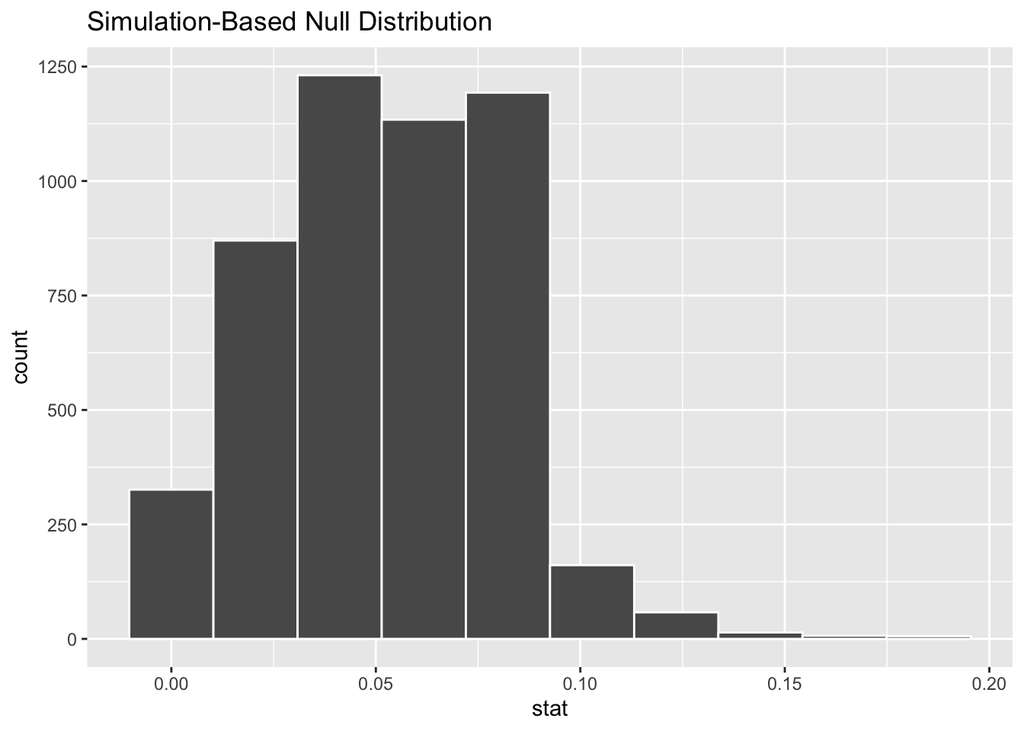

```r
null_distribution %>%
  visualise(bins = 10)
```

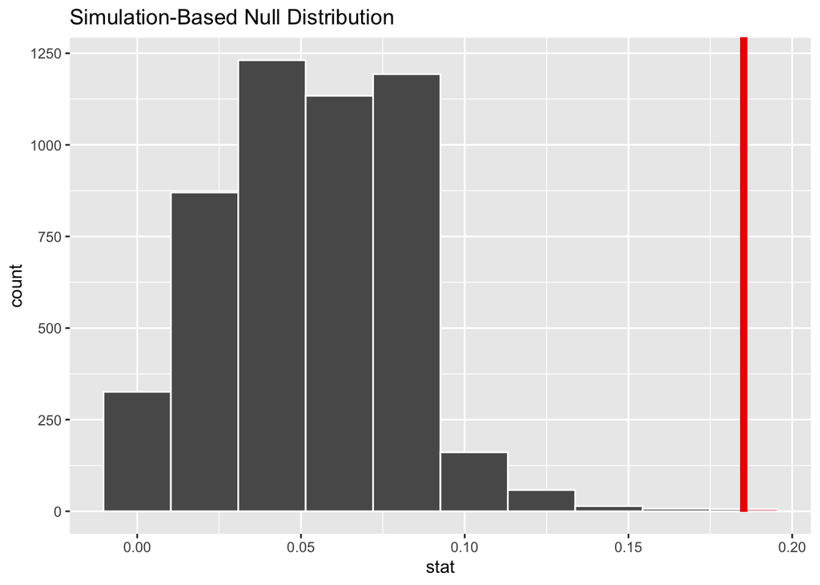

```r
# Our observed statistic is quite far to the right hand side of the null distribution
null_distribution %>%
  visualise(bins = 10) +
  shade_p_value(obs_stat = observed_stat, direction = "right") #it is a one-sided test as the alternative is whether the proportion is different in either left or left direction
```

```r
p_value <- null_distribution %>%
  get_p_value(obs_stat = observed_stat, direction = "right")

p_value
```

| p_value |
| --- |
| 0.0012 |

## Hypothesis testing - interpretation

# Task 1 Defining the Hypothesis

For the following three business problems write out H0 and Ha in both mathematical notation and in words. Also state the method you would use to generate the null distribution (bootstrap, permutation or simulation).

# 1. business scenario

You work for a independent coffee shop. The boss tells you that she thinks that around 40% of people in the town (population 30,000) know of the coffee shop, but you are skeptical of the estimate. You conduct a random survey of 200 people in the town, asking if respondents are aware of your coffee shop. You want to use the sample to test the hypothesis that 40% or more of the town’s population have heard of the coffee shop.

Test type: one-sample test proportion (comparing a proportion from one sample against a specified value), right-sided test

Statistic: p = 0.4 (sample proportion)

Generation of null distribution - simulate the null distribution (does not rely on our sample data, “flipping an unfair coin”).

# 2. business scenario

You work for a website design company and have performed an A/B test on the position of a banner on a website promoting a particular item. You selected five days at random last month and then randomly selected 200 of each sampled day’s users into group A and another 200 of that day’s users into group B. Group A continued to be shown the banner at the right hand side of the webpage (its usual position) while group B was shown the banner at the top of the page. You monitored each sampled user’s interactions with the website, in particular the ‘click through rate’ (CTR) on the banner, i.e. what proportion of sampled users clicked on the banner. You want to use the sampled data to test the hypothesis that website users overall are more likely to click on the banner if positioned at the top of the page

Test type: two-sample test proportion, independent samples, right-sided test H0: π (B) - π (A) = 0 # The proportion of people clicking on the banner positioned at the top of the page (B) is the same as the proportion of people clicking on the banner at usual position (A) Ha: π (B) - π (A) > 0

Statistic: p(B) - p(A) (difference in sample proportions)

Generation of null distribution - permute the null distribution (for H0, the position does not matter, “randomly shuffle the group A, B labels”). Then e calculate the diff in proportions for the two new groups. We repeat this eg. 10 000 times to create null distribution

# 3. business scenario

You work as an analyst for a car manufacturing company - they have specific standards they must meet for standards and regulation purposes. You have been asked to check the quality control of the manufacture of a particular car part. You have been given data on a sample of 200 parts produced over the period of a week (the sampled parts were pulled at random from the production line and measured: the factory produced a lot more than 200 parts that week). The specification of the part stipulates a width of 145mm, and the manufacturing process is said to have ‘drifted’ if the mean width of parts differs significantly from 145mm. You want to use the sampled measurements to test whether the process overall has drifted.

Test type: one-sample test mean (comparing the mean from one sample against a specified value), both-sided test

H0: μ (width) = 145 # We assume that every part measures a width of 145mm) Ha: μ (width) ≠ 145

Statistic: x sample mean

Generation of null distibution: bootstrap (sample with replacement) from our original sample, calculate the mean for the bootstrap sample, repeat this process many times (e.g. 10,000) to create the null distribution.

# Interpreting the results

For the 3 business problems stated above, imagine we performed you got the following p-values (with the given significance levels) write out your interpretation of the results.

Coffee shop problem. Significance level: 0.05, calculated p-value: 0.07 The p-value is greater than our significance level of 0.05. We failed to reject H0. Based on our sample, we do not have enough evidence that the proportion of people that heard of the coffee shop is statistically significantly greater than 40%.

Website company problem. Significance level: 0.01, p-value: 0.006 The p-value is less than our significance level. We reject H0 in favor of Ha. We found enough evidence in the sample to suggest that the website users overall are statistically significantly more likely to click on the banner if positioned at the top of the page (as of sample group B was presented with).

Manufacturing company problem. Significance level: 0.05, p-value: 0.55 The p-value is greater than our significance level. We failed to reject H0. Based on our sample of 200 parts, we do not have enough evidence to suggest that the width of parts statistically significantly differs from 145mm.